# Clean script

```r
library(ggplot2)
library(stringr)
library(gplots)
```

#### Loading the two datasets:

```r
load('MR_data.RData')#Load the Mendelian Randomization data frame
load('DrugBank_data.RData')#Load the Drugbank data frame
```

Overview:

```r
View(head(DB))
cbind(DB$drugbank.id,DB$name,DB$targets)[1:10,]#Here we bind the 3 columns that provide some
```

```
##       [,1]      [,2]
##  [1,] "DB00001" "Lepirudin"
##  [2,] "DB00002" "Cetuximab"
##  [3,] "DB00003" "Dornase alfa"
##  [4,] "DB00004" "Denileukin diftitox"
##  [5,] "DB00005" "Etanercept"
##  [6,] "DB00006" "Bivalirudin"
##  [7,] "DB00007" "Leuprolide"
##  [8,] "DB00008" "Peginterferon alfa-2a"
##  [9,] "DB00009" "Alteplase"
## [10,] "DB00010" "Sermorelin"
##       [,3]
##  [1,] "F2"
##  [2,] "EGFR/FCGR3B/C1R/C1QA/C1QB/C1QC/FCGR3A/C1S/FCGR1A/FCGR2A/FCGR2B/FCGR2C"
##  [3,] ""
##  [4,] "IL2RA/IL2RB/IL2RG"
##  [5,] "TNF/TNFRSF1B/FCGR1A/FCGR3A/FCGR2A/FCGR2B/FCGR2C/LTA/FCGR3B/C1S/C1R/C1QA/C1QB/C1QC"
##  [6,] "F2"
##  [7,] "GNRHR"
##  [8,] "IFNAR2/IFNAR1"
##  [9,] "PLG/FGA/PLAUR/SERPINE1"
## [10,] "GHRHR"
```

```r
                                               #information about the 10 first drugs
```

```r
head(MR)
```

```
##      gene_id       pvalue trait
## 1 AC010335.1 1.151219e-15    AD
## 2        ELL 1.151219e-15    AD
## 3      PTK2B 6.922158e-15    AD
## 4       SSR1 4.001775e-13    AD
## 5      AP3M1 1.764334e-12    AD
## 6    ARHGEF3 7.393724e-12    AD
```

#### Filtering missing values:

In the overview of the drugbank data we notice that drugs have missing gene targets.Here we filter the data by removing them:

```r
DB=DB[complete.cases(DB$targets),]#remove rows that have NA targets
rmrow=which(DB$targets=="")#vector containing the indexes of rows with empty values
DB=DB[-rmrow,] #Remove rows containing ''
```

As shown in the overview, gene names are seperated with ‘/’. A function was created in order to seperate strings of characters according to ‘/’ (useful to access targets one by one):

```r
unlisttarget=function(vec){
  vec=unlist(str_split(vec,pattern = '/'))
}
DB$targets=tapply(DB$targets,DB$drugbank.id,unlisttarget)
```

#### Creating a matrix P containing Traits and their P.values:

Matrix P contains the p.values of each causal gene according to the disease or trait:

```r
Genes=unique(MR$gene_id)#List containing all the gene names

Traits=unique(MR$trait)#List of all the traits studied

P=matrix(1,nrow = length(Genes),ncol=length(Traits),dimnames = list(Genes,Traits))


#The matrix will be filled by columns
#For each trait, all the p-values of the causal genes will be extracted


for (i in 1:length(Traits)){
c1=MR$trait==Traits[i]#Vector containing TRUE when the desired
                      #trait is present in a row
pos=which(c1)#Positions of the row
p.v=MR$pvalue[pos]#P-values of the trait
gen=MR$gene_id[pos]#Gene names for each p-value
P[gen,i]=p.v#Fill in the matrix at the desired positions
}
dim(P)
```

```
## [1] 15978    42
```

```r
head.matrix(P[,1:6],n=10)
```

```
##                      AD        ALS         BASO          BMI         CAD
## AC010335.1 1.151219e-15 0.09500669 8.779308e-08 2.001331e-01 0.133984972
## ELL        1.151219e-15 0.09500669 8.779308e-08 2.001331e-01 0.133984972
## PTK2B      6.922158e-15 0.85924407 5.111168e-02 3.487243e-03 0.001621889
## SSR1       4.001775e-13 0.09495719 3.485468e-01 2.931925e-01 0.206949276
## AP3M1      1.764334e-12 0.26942491 1.897301e-01 8.008671e-03 0.011632994
## ARHGEF3    7.393724e-12 0.06717056 8.130884e-01 3.715537e-01 0.054652970
## TP53INP1   8.241628e-12 0.55461095 3.549094e-07 8.085134e-03 0.003461327
## ARL5B      1.001342e-11 0.99224396 2.419640e-02 5.255013e-02 0.984072531
## FNBP4      1.266168e-11 0.14016729 2.685093e-01 3.953607e-05 0.734256541
## MS4A4A     1.490596e-11 0.12852038 2.173400e-03 7.827340e-01 0.211120149
##                      CD
## AC010335.1 1.473200e-09
## ELL        1.473200e-09
## PTK2B      1.239448e-06
## SSR1       3.561979e-02
## AP3M1      1.551524e-01
## ARHGEF3    4.367540e-10
## TP53INP1   2.522284e-01
## ARL5B      6.271887e-01
## FNBP4      3.153598e-01
## MS4A4A     7.516781e-01
```

Sanity check for trait 1 (AD):

```r
pval_AD=MR$pvalue[MR$trait==Traits[1]]
isFALSE(pval_AD%in%P[,1])#Should be correct
```

```
## [1] FALSE
```

#### Creating a matrix Q containing Drugs+their gene targets:

Now, i want to create a matrix Q that contains 0 and 1 for each gene and each drug: - 0 if the drug does not target the gene - 1 if the drug targets the gene

-> This will be helpful for determining the number of targets for each drug (for the association matrix)

```r
Drugs=unique(DB$drugbank.id)
Q=matrix(0,ncol = length(Drugs),nrow = length(Genes),dimnames = list(Genes,Drugs))
for (i in 1:length(Drugs)){
  tl=DB$targets[[i]]#tl contains the target(s) of the drug
  index=which(Genes%in%tl)#index contains the positions of the targets in the gene vector
  Q[index,i]=1
}
dim(Q)
```

```
## [1] 15978  7063
```

```r
head.matrix(Q[,1:10],n=10)
```

```
##            DB00001 DB00002 DB00004 DB00005 DB00006 DB00007 DB00008 DB00009
## AC010335.1       0       0       0       0       0       0       0       0
## ELL              0       0       0       0       0       0       0       0
## PTK2B            0       0       0       0       0       0       0       0
## SSR1             0       0       0       0       0       0       0       0
## AP3M1            0       0       0       0       0       0       0       0
## ARHGEF3          0       0       0       0       0       0       0       0
## TP53INP1         0       0       0       0       0       0       0       0
## ARL5B            0       0       0       0       0       0       0       0
## FNBP4            0       0       0       0       0       0       0       0
## MS4A4A           0       0       0       0       0       0       0       0
##            DB00010 DB00011
## AC010335.1       0       0
## ELL              0       0
## PTK2B            0       0
## SSR1             0       0
## AP3M1            0       0
## ARHGEF3          0       0
## TP53INP1         0       0
## ARL5B            0       0
## FNBP4            0       0
## MS4A4A           0       0
```

Rows of Q represent genes (around 16k) Columns of Q represent drugs (around 7k drugs)

We see at first glance that drugs do not have many gene targets (This will be visualized in a later part)

If we sum the columns of Q, we obtain the total number of targets for each drug:

```r
t=colSums(Q)
t[1:20]
```

```
## DB00001 DB00002 DB00004 DB00005 DB00006 DB00007 DB00008 DB00009 DB00010
##       1       9       2       9       1       0       2       3       1
## DB00011 DB00012 DB00013 DB00014 DB00015 DB00016 DB00017 DB00018 DB00019
##       2       1       7       0       3       1       0       2       2
## DB00020 DB00021
##       1       0
```

We see that some drugs have 0 targets. Given that we are interested in drugs having an effect on phenotypes coded by causal genes, we remove them.

```r
tar=which(t==0)#A vector containing the positions of drugs that have 0 targets
Q_tar=Q[,-tar]
t=colSums(Q_tar)
t[1:20]
```

```
## DB00001 DB00002 DB00004 DB00005 DB00006 DB00008 DB00009 DB00010 DB00011
##       1       9       2       9       1       2       3       1       2
## DB00012 DB00013 DB00015 DB00016 DB00018 DB00019 DB00020 DB00022 DB00024
##       1       7       3       1       2       2       1       2       1
## DB00025 DB00026
##       7       1
```

```r
which(t==0)
```

```
## named integer(0)
```

Drugs, with 0 targets were removed from the matrix. We can subset these drugs from the original data frame aswell:

```r
DB_tar=subset(DB,DB$drugbank.id%in%colnames(Q_tar))
```

#### Obtaining the association matrix (R) :

In order to obtain the association between drugs and traits, we multiply Q and R according to this formula:
$$R={\frac{1}{t}}\times{-log10(P)^T}\times{Q}$$
Where:

-R is the association matrix

-t is the number of targets for each drug

-P is the matrix containing the p-values for each gene

-Q contains drugs and the number of targets

-> We want to sum the -log10 of P.values for each association

-> We divide by the number of targets (number of genes targeted by the drug) to normalize the strength of the association:

- If a drug targets only one gene then it will be penalized : Other drugs with weaker association but target multiple genes will have a higher association strength overall (Because we sum the p.values for each gene that is targeted by the drug)

##### log transformation of P:

```r
lP=-log10(P)
max(lP)
```

```
## [1] 117.7008
```

```r
min(lP)
```

```
## [1] 0
```

```r
which(is.na(lP))
```

```
## integer(0)
```

```r
which(is.infinite(lP))
```

```
## integer(0)
```

Here the -log10 transformation did not yield NA or inf values because, in the P matrix, missing genes for a trait were assigned a p-value of 1. This means that when they are -log10 transformed their score will be 0.

```r
head.matrix(lP[,1:6],n=10)
```

```
##                  AD         ALS       BASO       BMI         CAD        CD
## AC010335.1 14.93884 1.022245793 7.05653972 0.6986811 0.872943910 8.8317383
## ELL        14.93884 1.022245793 7.05653972 0.6986811 0.872943910 8.8317383
## PTK2B      14.15976 0.065883458 1.29147982 2.4575178 2.789978930 5.9067715
## SSR1       12.39775 1.022472149 0.45773892 0.5328472 0.684136088 1.4483086
## AP3M1      11.75342 0.569562260 0.72186386 2.0964395 1.934308500 0.8092415
## ARHGEF3    11.13114 1.172821037 0.08986225 0.4299784 1.262386231 9.3597631
## TP53INP1   11.08399 0.256011559 6.44988252 2.0923128 2.460757330 0.5982059
## ARL5B      10.99942 0.003381536 1.61624916 1.2794262 0.006972891 0.2026018
## FNBP4      10.89751 0.853353312 0.57104067 4.4030065 0.134152176 0.5011937
## MS4A4A     10.82664 0.891027991 2.66286043 0.1063858 0.675470317 0.1239681
```

##### Multiplication:

```r
R=t(lP)%*%Q_tar
head.matrix(R[1:10,1:10])
```

```
##          DB00001   DB00002   DB00004   DB00005     DB00006   DB00008
## AD   0.000000000  2.922388 2.2428984  2.627918 0.000000000 0.3628774
## ALS  0.564340359 11.023857 1.3378391 10.830364 0.564340359 2.0473498
## BASO 0.385841318 16.084281 2.7535770 15.777563 0.385841318 0.3751547
## BMI  0.000000000  3.687918 0.1517365  3.758741 0.000000000 1.7034322
## CAD  0.160469842  2.371039 0.5227172  3.269912 0.160469842 1.1813525
## CD   0.009221253  5.675658 1.6657103  5.743531 0.009221253 0.6871317
##       DB00009    DB00010   DB00011    DB00012
## AD   2.187038 0.57260964 0.3628774 0.21437647
## ALS  2.060445 0.02898310 2.0473498 1.94004777
## BASO 6.058007 0.08768897 0.3751547 0.09661587
## BMI  2.464554 0.08767210 1.7034322 0.35288581
## CAD  2.835698 0.53364544 1.1813525 1.60419162
## CD   0.776974 0.20408331 0.6871317 0.05463131
```

##### Normalization:

Each row is divided by the number of targets for each drug:

```r
for (i in 1:dim(R)[1]){
  R[i,]=R[i,]/t#Each row (trait) is divided by t
                #t is the number of targets for each column (drug)
}
head.matrix(R[1:10,1:10])
```

```
##          DB00001   DB00002    DB00004   DB00005     DB00006   DB00008
## AD   0.000000000 0.3247098 1.12144919 0.2919909 0.000000000 0.1814387
## ALS  0.564340359 1.2248730 0.66891956 1.2033738 0.564340359 1.0236749
## BASO 0.385841318 1.7871424 1.37678852 1.7530626 0.385841318 0.1875773
## BMI  0.000000000 0.4097687 0.07586827 0.4176379 0.000000000 0.8517161
## CAD  0.160469842 0.2634488 0.26135862 0.3633236 0.160469842 0.5906763
## CD   0.009221253 0.6306286 0.83285514 0.6381702 0.009221253 0.3435659
##        DB00009    DB00010   DB00011    DB00012
## AD   0.7290128 0.57260964 0.1814387 0.21437647
## ALS  0.6868150 0.02898310 1.0236749 1.94004777
## BASO 2.0193355 0.08768897 0.1875773 0.09661587
## BMI  0.8215180 0.08767210 0.8517161 0.35288581
## CAD  0.9452326 0.53364544 0.5906763 1.60419162
## CD   0.2589913 0.20408331 0.3435659 0.05463131
```

#### Visualising the data:

##### Distribution of the P.values for the traits:

Baseline scores for each trait:

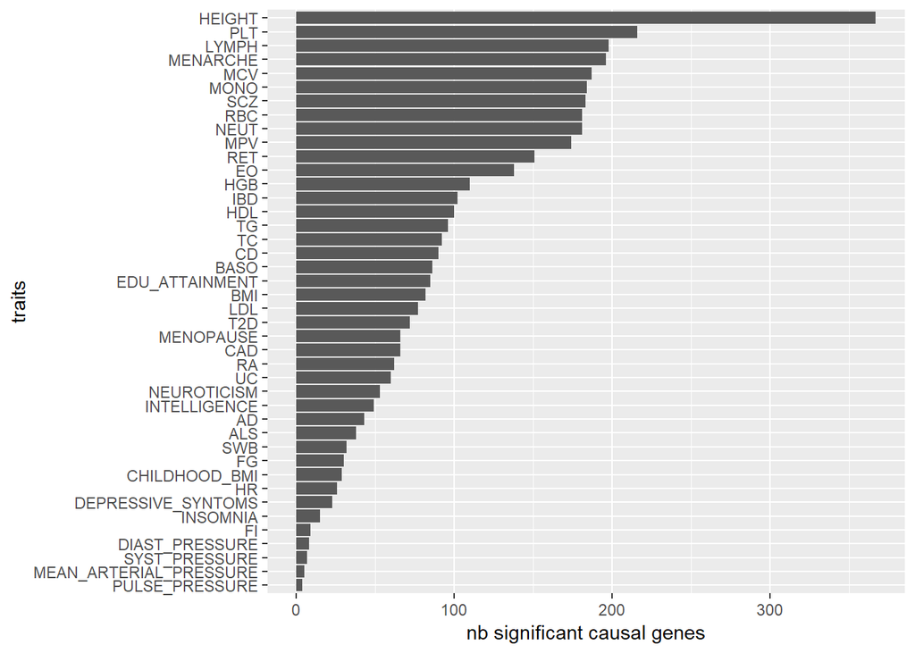

```r
#Threshol set at
#(0.05/42)*16000*10^-8
#or
#-log10(1.9*10^-7)
#Round to 7
S=lP>7#Matrix of boolean values. If the P-value is significant then the value is TRUE
df=data.frame(counts=colSums(S),trait=names(colSums(S)))

ggplot(data =df ,  aes(x=reorder(trait,counts),y=counts)) +
  geom_bar(stat='identity')+coord_flip()+labs(x='traits',y='nb significant causal genes')
```

Save figure:

```r
pdf('Figures/barplot.pdf')
ggplot(data =df ,  aes(x=reorder(trait,counts),y=counts)) +
  geom_bar(stat='identity')+coord_flip()+labs(x='traits',y='nb significant causal genes')
dev.off()
```

Summing up the TRUE values in each column tells us how many genes are significantly causal to the trait

```r
sort(colSums(S),decreasing = T)
```

```
##                 HEIGHT                    PLT                  LYMPH
##                    367                    216                    198
##               MENARCHE                    MCV                   MONO
##                    196                    187                    184
##                    SCZ                   NEUT                    RBC
##                    183                    181                    181
##                    MPV                    RET                     EO
##                    174                    151                    138
##                    HGB                    IBD                    HDL
##                    110                    102                    100
##                     TG                     TC                     CD
##                     96                     92                     90
##                   BASO         EDU_ATTAINMENT                    BMI
##                     86                     85                     82
##                    LDL                    T2D                    CAD
##                     77                     72                     66
##              MENOPAUSE                     RA                     UC
##                     66                     62                     60
##            NEUROTICISM           INTELLIGENCE                     AD
##                     53                     49                     43
##                    ALS                    SWB                     FG
##                     38                     32                     30
##          CHILDHOOD_BMI                     HR     DEPRESSIVE_SYNTOMS
##                     29                     26                     23
##               INSOMNIA                     FI         DIAST_PRESSURE
##                     15                      9                      8
##          SYST_PRESSURE MEAN_ARTERIAL_PRESSURE         PULSE_PRESSURE
##                      7                      5                      4
```

We see that Height has the most significant causal genes (has the highest scores across traits), it means that this trait is controlled by multiple genes that we know are directly causal for the trait (highly genetic). The least genetic traits are the traits associated with blood pressure, fasting insulin and insomnia.

Investigating the significant genes for the 10 diseases:

```r
int_dis=c('UC','T2D','IBD','INSOMNIA','TG','HDL','TC','LDL','HR','SCZ')
cand_gen=list()
for (i in 1:length(int_dis)){
  cand_gen[[i]]=names(which(S[,int_dis[i]]==TRUE))
}
names(cand_gen)=int_dis
str(cand_gen)
```

```
## List of 10
##  $ UC      : chr [1:60] "DMPK" "TBKBP1" "APOLD1" "THBS3" ...
##  $ T2D     : chr [1:72] "TP53INP1" "PLEKHA1" "RPL8" "SOCS5" ...
##  $ IBD     : chr [1:102] "PTK2B" "DMPK" "TBKBP1" "C8orf40" ...
##  $ INSOMNIA: chr [1:15] "MYBPC3" "CENPV" "S100A13" "PDCD2" ...
##  $ TG      : chr [1:96] "SCARB1" "RAB3IL1" "GSTA1" "XKR6" ...
##  $ HDL     : chr [1:100] "C1QTNF4" "LACTB" "MMAB" "FOXRED1" ...
##  $ TC      : chr [1:92] "C1QTNF4" "TBKBP1" "DAGLB" "ZNF91" ...
##  $ LDL     : chr [1:77] "TBKBP1" "TMEM230" "CORO1B" "ELP5" ...
##  $ HR      : chr [1:26] "EIF4E3" "CDC14A" "ACTN4" "NEDD1" ...
##  $ SCZ     : chr [1:183] "SSR1" "WDR55" "MAPK3" "NDUFA2" ...
```

```r
#Cand_gen is a list of candidate genes causal for diseases for functional follow up studies
```

##### Distribution of the scores for the genes:

Visualising pleiotropic genes:

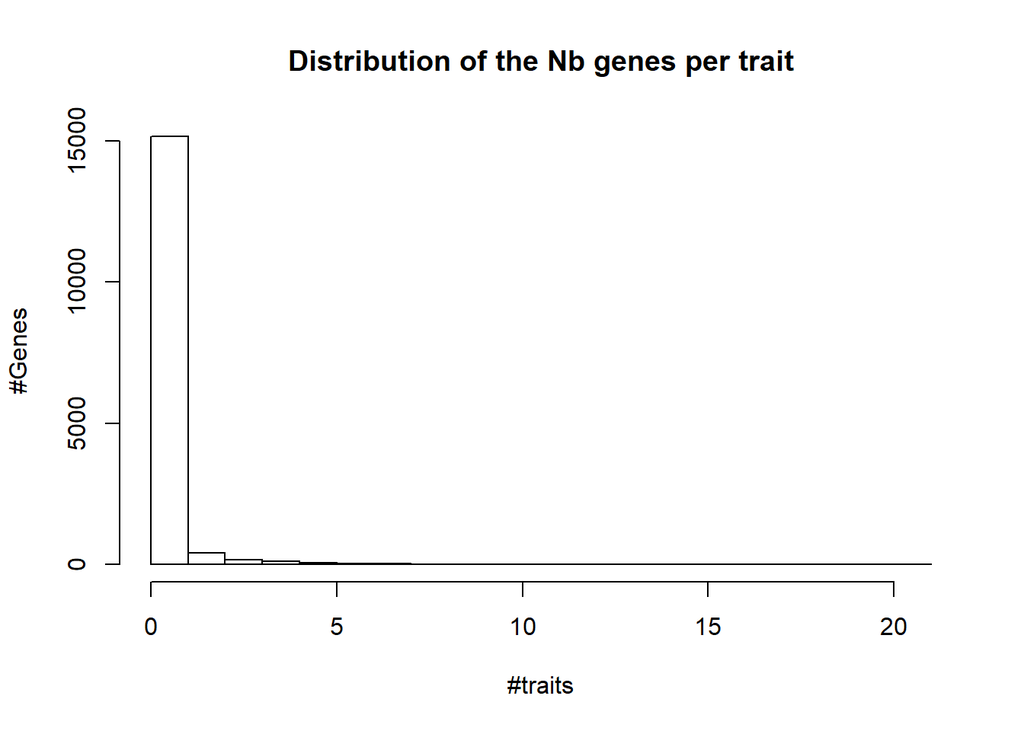

```r
hist(rowSums(S),main='Distribution of the Nb genes per trait',ylab='#Genes',xlab='#traits')
```

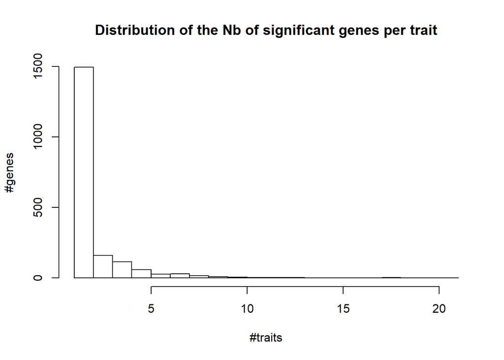

```r
S_n0=subset(rowSums(S),rowSums(S)>0)
hist(S_n0,main='Distribution of the Nb of significant genes per trait',ylab='#genes',xlab='#traits',breaks=1:21)
```

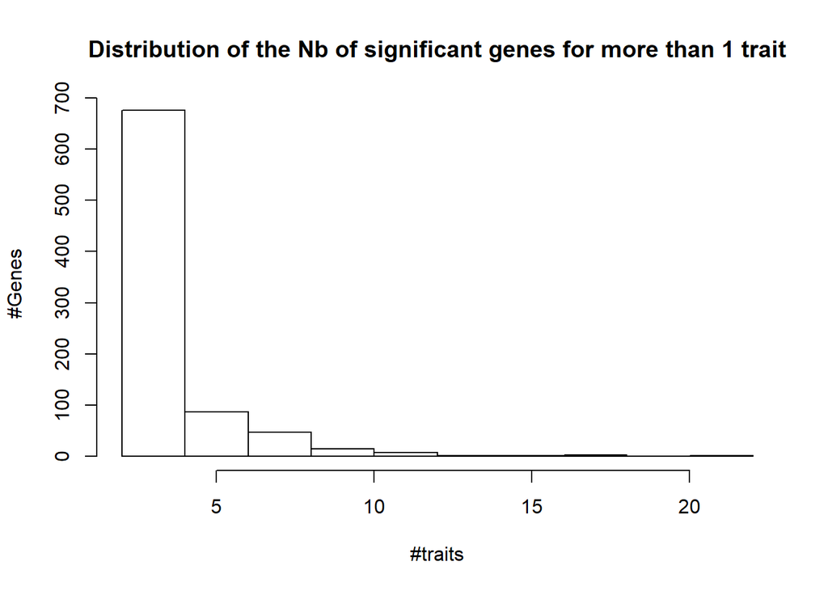

```r
#(14049 genes were not significant, only 1929 were)
S_n1=subset(rowSums(S),rowSums(S)>1)
hist(S_n1,main='Distribution of the Nb of significant genes for more than 1 trait',ylab='#Genes',xlab='#traits')
```

The histograms represent the distribution of the genes that are significantly causal to a number of traits We saw in the non-log transformed plot that the majority of genes are not significantly causal to any trait. The aim of this histogram is to identify the pleiotropic genes that control multiple traits. If these genes are identified, it would be unwise to target them, as their pleiotropy makes it difficult to isolate the treatment for a spceific disease –> the strategy would be to target genes that are causal to only one trait ideally.

```r
pdf('Figures/genes_trait_hist.pdf')
hist(S_n0,main='Distribution of the nb of significant genes per trait',ylab='#genes',xlab='#traits',breaks=1:21)
dev.off()
```

```r
sum(rowSums(S)>0)#number of genes significant for at least one trait
```

```
## [1] 1929
```

```r
sort(rowSums(S),decreasing = T)[1:30]
```

```
##           BLK          XKR6       TMEM258 RP11-467L20.9       FAM167A
##            21            18            18            17            15
##          MSRA         FADS1         LIME1        SEC16A    AC087269.1
##            13            13            12            12            12
##        CLDN23          GGT7       SULT1A1        FAM43A         MAPK3
##            12            11            11            11            10
##         THBS3       CCDC101         FDFT1         MTMR9         APOBR
##            10            10            10            10            10
##        GLYCTK         ABCB9         PPP4C        DCAF12           CKB
##            10             9             9             9             9
##          PLTP RP11-264B17.3       ALDH8A1          BRD3         KLRC1
##             9             9             9             9             8
```

These are the most pleiotropic genes, these maybe not worth to target with drugs:

- The first gene, BLK, codes for a tyrosin-protein kinase involved in B-lymphocyte development differentiation and signalling. Mutations in this gene causes maturity-onset diabetes of the young. https://www.ncbi.nlm.nih.gov/pubmed/19667185
- XKR6 codes for a protein related to the Xk-family domain, involved in sodium dependent transport of neutral amino acids. These proteins are responsible for the Kx blood group system, and defects results in McLeod syndrome (late onset abnormalities in the neuromuscular and hematopoeitic systems).
- TMEM258 codes for a subunit of oligosaccharyl transferase (OST) complex. It is involved in the pathway protein glycosilation

##### Distribution of the number of gene targets per drug:

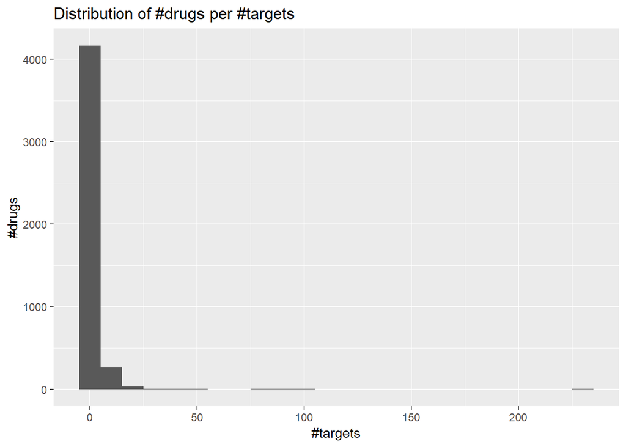

```r
df=data.frame(targets=colSums(Q_tar))
ggplot(data = df,aes(x=targets))+geom_histogram(binwidth=10)+labs(title='Distribution of #drugs per #targets',y='#drugs',x='#targets')
```

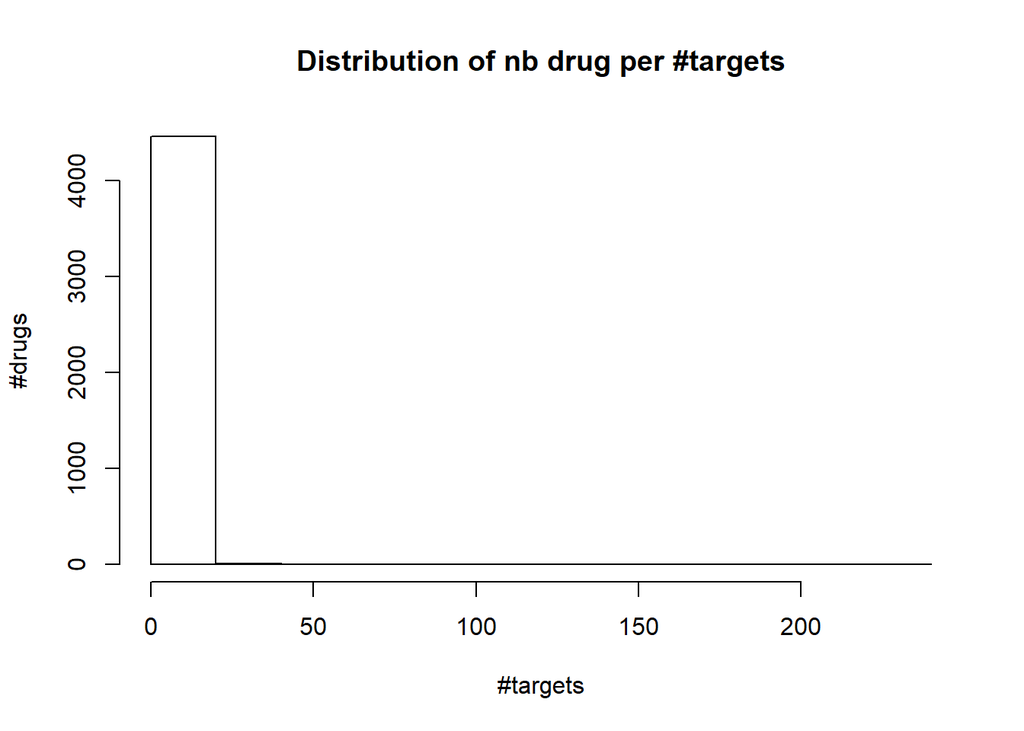

```r
hist(colSums(Q_tar),main='Distribution of nb drug per #targets',ylab='#drugs',xlab='#targets')
```

log10 scale:

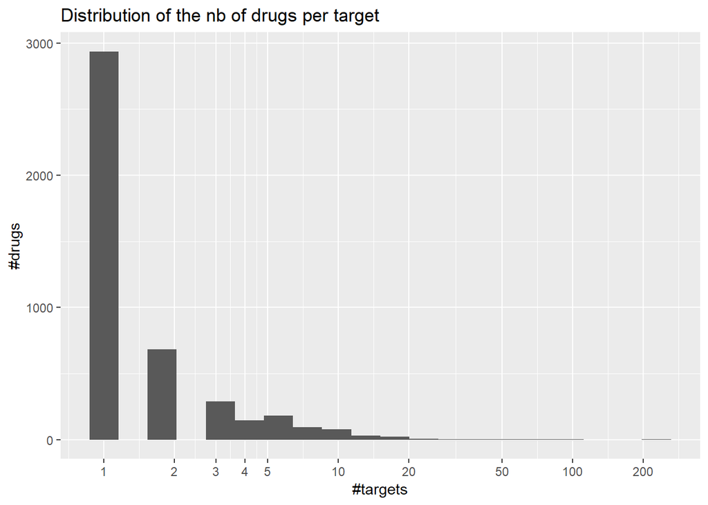

```r
ggplot(data = df,aes(x=targets))+geom_histogram(bins=20)+labs(title='Distribution of the nb of drugs per target',y='#drugs',x='#targets')+scale_x_continuous(trans = 'log10',breaks=c(1,2,3,4,5,10,20,50,100,200))
```

Proportion of drugs that have more than 1 target:

```r
sum(df$targets>1)/length(df$targets)
```

```
## [1] 0.3442733
```

save it:

```r
pdf('Figures/drugs_targets_hist.pdf')
ggplot(data = df,aes(x=targets))+geom_histogram(bins=20)+labs(title='Distribution of the nb of drugs per target',y='#drugs',x='#targets')+scale_x_continuous(trans = 'log10',breaks=c(1,2,3,4,5,10,20,50,100,200))
dev.off()
```

#### Visualizing the drug trait matrix:

Histogram:

```r
lR=-log10(R)
max(lR)
```

```
## [1] Inf
```

```r
max(lR[!is.infinite(lR)])
```

```
## [1] 5.583209
```

```r
lR[is.infinite(lR)]=max(lR[!is.infinite(lR)])
max(lR)
```

```
## [1] 5.583209
```

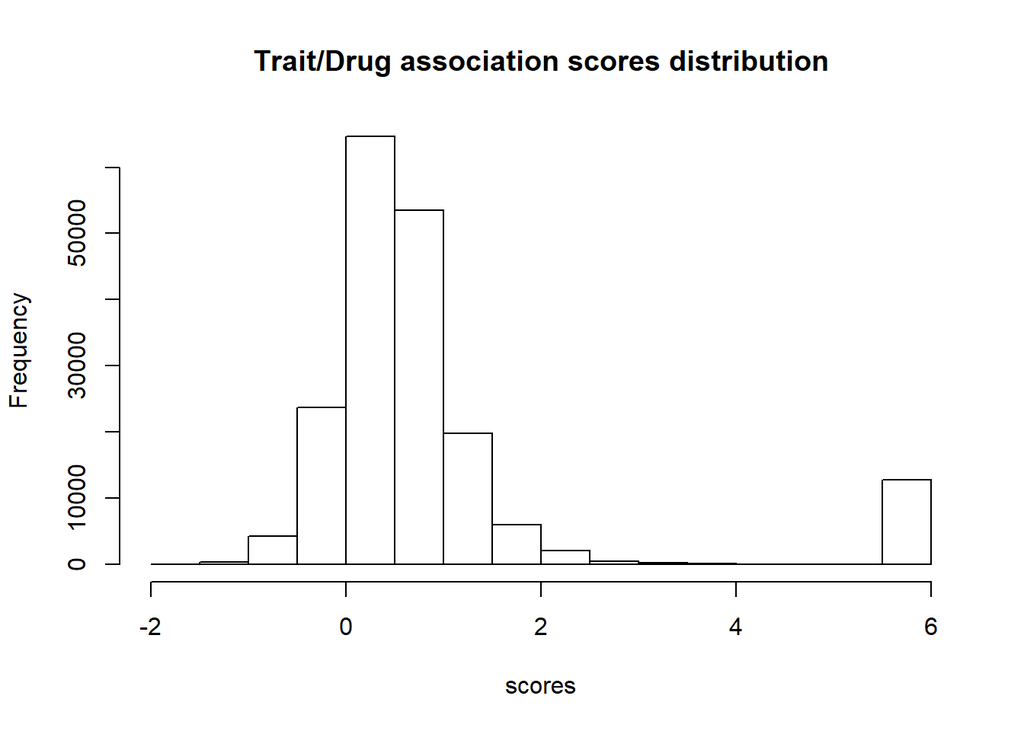

```r
hist(lR,main='Trait/Drug association scores distribution',xlab='scores')
```

We see that few drugs have a high association score with diseases.

```r
pdf('Figures/scores_hist.pdf')
hist(lR,main='Trait/Drug association scores distribution',xlab='scores')
dev.off()
```

The heatmap:

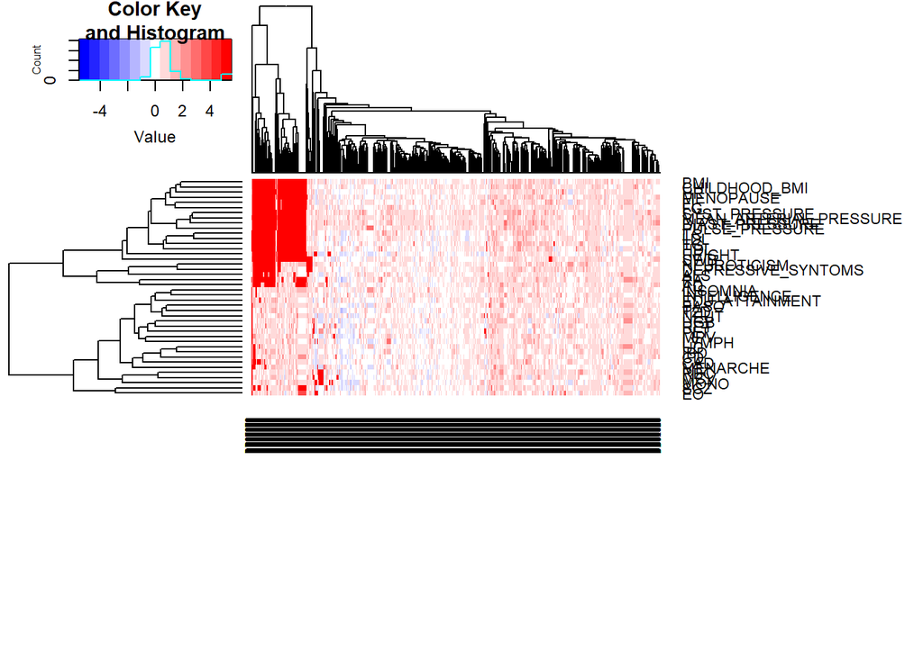

```r
heatmap.2(lR,trace = 'none',margins=c(12,12),col=colorRampPalette(c('blue','White','red')))
```

Subsetting the cluster of high scores:

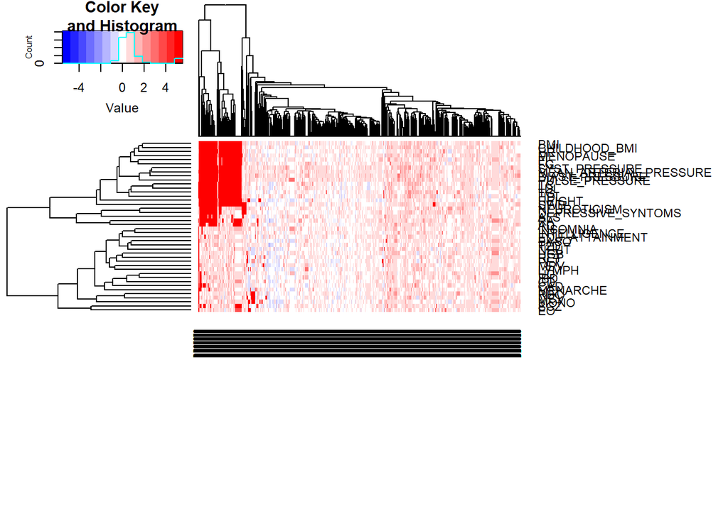

```r
hm=heatmap.2(lR,trace = 'none',margins=c(12,12),col=colorRampPalette(c('blue','White','red')))
```

```r
m=t(hm$carpet)#Get the matrix as clustered in the heatmap
nam=colnames(m[1:21,1:1000])
```

Saving it:

```r
pdf(file = 'Figures/heatmap.pdf',height = 16,width =20)
heatmap.2(lR,trace = 'none',margins=c(12,14),col=colorRampPalette(c('blue','White','red')),main='Trait/drug association scores',cexRow=1)
dev.off()
```

#### Finding hits (drugs) for a trait in the Drugbank database:

##### Function that plots hits, and the rest of the drug scores on a boxplot, and returns the p-value of the rank-sum test:

```r
find_hits_to_vis=function(keywords,categories,trait,DB_tar,lR){

  des=DB_tar$description
  indi=DB_tar$indication
  cat=DB_tar$categories

hits_indi_des_list=list()
for (i in 1:length(keywords)){

posd=grep(keywords[i],des,ignore.case = T)

hitsd=DB_tar$drugbank.id[posd]

posi=grep(keywords[i],indi,ignore.case = T)
hitsi=DB_tar$drugbank.id[posi]

hits_indi_des=unique(hitsd,hitsi)
hits_indi_des_list[[i]]=hits_indi_des
}


hits_cat_list=list()
for (j in 1:length(categories)){
posc=grep(categories[j],cat,ignore.case = T)
hitsc=DB_tar$drugbank.id[posc]
hits_cat_list[[j]]=hitsc
}


hits_id=unique(unlist(hits_cat_list,hits_indi_des_list))
hits_names=DB_tar$name[DB_tar$drugbank.id%in%hits_id]

hits_ind=which(colnames(lR)%in%hits_id)
hits_scores=lR[paste(trait),hits_ind]

rest_scores=lR[paste(trait),-hits_ind]
rest_scores_names=DB_tar$name[DB_tar$drugbank.id%in%names(rest_scores)]

dat.hits=data.frame(drugs='hits',score=hits_scores,names=hits_names)
dat.rest=data.frame(drugs='rest',score=rest_scores,names=rest_scores_names)
dat.plot=rbind(dat.hits,dat.rest)
plot=ggplot(dat.plot, aes(x=drugs, y=score,label=names))+
  geom_boxplot()+ggtitle(paste('Association scores with ',trait))
plot=plot+theme(plot.title = element_text(size = 20,face = 'bold',hjust = 0.5))
logplot=plot

wilc=wilcox.test(hits_scores,rest_scores)
ttes=t.test(hits_scores,rest_scores)

result=list(plot=logplot,ranksum.test=wilc,
            student.test=ttes,hits=hits_names,
            rest_high_score=dat.rest$names[dat.rest$score==max(lR)])

if(max(dat.rest$score)==max(dat.hits$score)){
  result$rest_high_score=dat.rest$names[dat.rest$score==max(dat.hits$score)]
  }


return(result)

}
```

##### Insomnia:

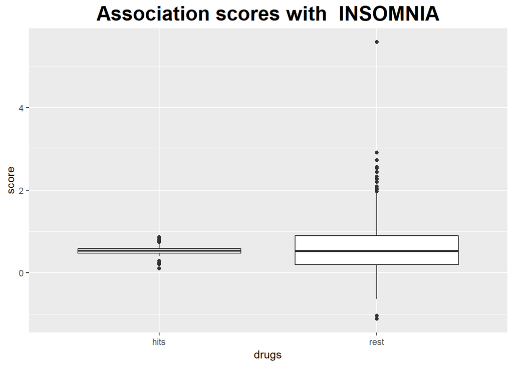

```
##
## $ranksum.test
##
##  Wilcoxon rank sum test with continuity correction
##
## data:  hits_scores and rest_scores
## W = 118320, p-value = 0.9125
## alternative hypothesis: true location shift is not equal to 0
##
##
## $student.test
##
##  Welch Two Sample t-test
##
## data:  hits_scores and rest_scores
## t = -3.4576, df = 74.778, p-value = 0.0009026
## alternative hypothesis: true difference in means is not equal to 0
## 95 percent confidence interval:
##  -0.12533592 -0.03370158
## sample estimates:
## mean of x mean of y
## 0.5372942 0.6168130
##
##
## $hits
##  [1] "Lorazepam"           "Ethchlorvynol"       "Temazepam"
##  [4] "Butabarbital"        "Butalbital"          "Etomidate"
##  [7] "Talbutal"            "Pentobarbital"       "Meprobamate"
## [10] "Eszopiclone"         "Alprazolam"          "Secobarbital"
## [13] "Zolpidem"            "Methohexital"        "Chlordiazepoxide"
## [16] "Thiopental"          "Midazolam"           "Flurazepam"
## [19] "Scopolamine"         "Propiomazine"        "Primidone"
## [22] "Propofol"            "Diazepam"            "Oxazepam"
## [25] "Methylphenobarbital" "Triazolam"           "Remifentanil"
## [28] "Zaleplon"            "Ramelteon"           "Melatonin"
## [31] "Diphenhydramine"     "Methyprylon"         "Thiamylal"
## [34] "Phenobarbital"       "Zopiclone"           "Estazolam"
## [37] "Amobarbital"         "Aprobarbital"        "Butethal"
## [40] "Heptabarbital"       "Hexobarbital"        "Glutethimide"
## [43] "Barbital"            "Flunitrazepam"       "Bromazepam"
```

[output cut: 12 more lines]

```
##  [8] Vecuronium
##  [9] Phosphoaminophosphonic Acid Guanylate Ester
## [10] Galiximab
## [11] Dapagliflozin
## [12] (2S)-2-({6-[(3-amino-5-chlorophenyl)amino]-9-isopropyl-9H-purin-2-yl}amino)-3-methylbutan-1-ol
## [13] N~2~-1H-benzimidazol-5-yl-N~4~-(3-cyclopropyl-1H-pyrazol-5-yl)pyrimidine-2,4-diamine
## [14] 3,7,3',4'-TETRAHYDROXYFLAVONE
## [15] 4,4'-BIS([H]METHYLSULFONYL)-2,2',5,5'-TETRACHLOROBIPHENYL
## [16] Gabapentin Enacarbil
## [17] Hexamethonium
## [18] Empagliflozin
## [19] Alirocumab
## [20] Potassium perchlorate
## [21] Ertugliflozin
## 4426 Levels: '5'-O-(N-(L-Alanyl)-Sulfamoyl)Adenosine ...
```

```r
keywords=c('insomnia','sleep','hypnotic','antidepressant','anti-depressent')
categories=c('Benzodiazepine hypnotics and sedatives','Hypnotics and Sedatives')
trait='INSOMNIA'
find_hits_to_vis(keywords,categories,trait,DB_tar,lR)
```

##### Inflammatory Bowel Disease(IBD):

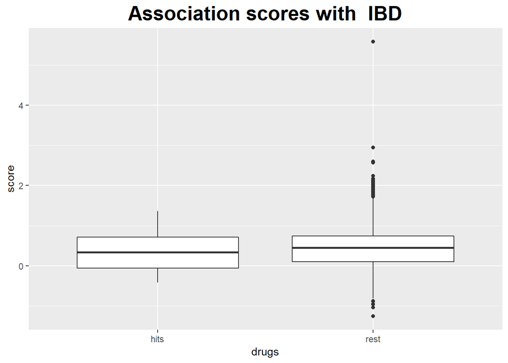

```
##
## $ranksum.test
##
##  Wilcoxon rank sum test with continuity correction
##
## data:  hits_scores and rest_scores
## W = 38638, p-value = 0.3023
## alternative hypothesis: true location shift is not equal to 0
##
##
## $student.test
##
##  Welch Two Sample t-test
##
## data:  hits_scores and rest_scores
```

[output cut: 73 more lines]

```r
keywords=c('inflammatory bowel disease','gastroenteritis')
categories=c('Antidiarrheals, Intestinal Antiinflammatory/antiinfective Agents')
trait='IBD'
find_hits_to_vis(keywords,categories,trait,DB_tar,lR)
```

##### Type 2 Diabetes:

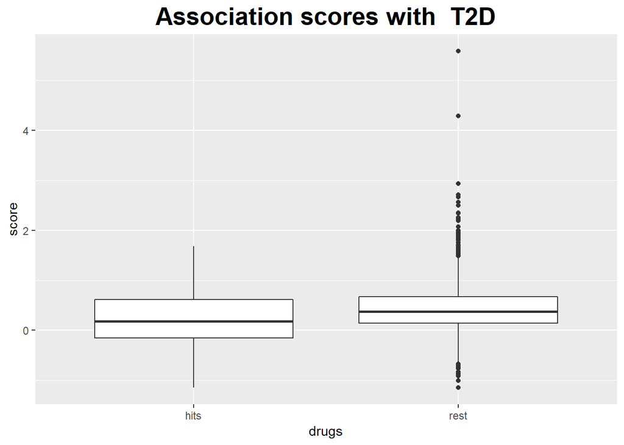

```
##
## $ranksum.test
##
##  Wilcoxon rank sum test with continuity correction
##
## data:  hits_scores and rest_scores
## W = 93525, p-value = 0.003158
## alternative hypothesis: true location shift is not equal to 0
##
##
## $student.test
##
##  Welch Two Sample t-test
##
## data:  hits_scores and rest_scores
## t = -2.756, df = 55.115, p-value = 0.007918
## alternative hypothesis: true difference in means is not equal to 0
## 95 percent confidence interval:
##  -0.42854843 -0.06770591
## sample estimates:
## mean of x mean of y
## 0.1976653 0.4457924
##
##
## $hits
##  [1] "Insulin Human"     "Insulin Lispro"    "Insulin Glargine"
##  [4] "Insulin Pork"      "Troglitazone"      "Glimepiride"
##  [7] "Disopyramide"      "Acarbose"          "Metformin"
## [10] "Rosiglitazone"     "Acetohexamide"     "Quinine"
## [13] "Miglitol"          "Simvastatin"       "Chlorpropamide"
## [16] "Nateglinide"       "Pentamidine"       "Mifepristone"
## [19] "Tolazamide"        "Repaglinide"       "Phenformin"
## [22] "Sulfamethoxazole"  "Glyburide"         "Glipizide"
## [25] "Gliclazide"        "Tolbutamide"       "Pioglitazone"
## [28] "Bromocriptine"     "Gliquidone"        "Mitiglinide"
## [31] "Sitagliptin"       "Sunitinib"         "Mecasermin"
## [34] "Pramlintide"       "Insulin Aspart"    "Insulin Detemir"
## [37] "Insulin Glulisine" "Glycodiazine"      "Tolrestat"
## [40] "Vildagliptin"      "Voglibose"         "NN344"
## [43] "AMG-222"           "KRP-104"           "Alogliptin"
## [46] "Dapagliflozin"     "Saxagliptin"       "Gosogliptin"
## [49] "Linagliptin"       "Canagliflozin"     "Empagliflozin"
## [52] "Lobeglitazone"     "Ciglitazone"       "Insulin Degludec"
## [55] "Dutogliptin"
##
## $rest_high_score
##  [1] Chloroquine
##  [2] Farnesol
##  [3] Fexaramine
##  [4] Biopterin
##  [5] 2-ACETAMIDO-2-DEOXY-BETA-D-GLUCOPYRANOSE(BETA1-4)-2-ACETAMIDO-1,6-ANHYDRO-3-O-[(R)-1-CARBOXYETHYL]-2-DEOXY-BETA-D-GLUCOPYRANOSE-L-ALANYL-GAMMA-D-GLUTAMYL-MESO-DIAMINOPIMELYL-D-ALANINE
##  [6] Galiximab
##  [7] Obinepitide
##  [8] Obeticholic acid
##  [9] (2S)-2-({6-[(3-amino-5-chlorophenyl)amino]-9-isopropyl-9H-purin-2-yl}amino)-3-methylbutan-1-ol
## [10] 3,7,3',4'-TETRAHYDROXYFLAVONE
## [11] 4,4'-BIS([H]METHYLSULFONYL)-2,2',5,5'-TETRACHLOROBIPHENYL
## [12] Gabapentin Enacarbil
## [13] Alirocumab
## [14] Oxetacaine
## 4424 Levels: '5'-O-(N-(L-Alanyl)-Sulfamoyl)Adenosine ...
```

```r
keywords=c('anti-diabetic','insulin receptor','glucose','type 2 diabetes','type II diabetes','antihyperglycemic','anti-hyperglycemic','hypoglycemic','anti-diabetic drug','insulin resistance')
categories=c('Blood Glucose Lowering Agents','Sodium-glucose Cotransporter 2 (SGLT2) Inhibitors','Drugs Used in Diabetes','Sodium-Glucose Transporter 2 Inhibitors')
trait='T2D'
find_hits_to_vis(keywords,categories,trait,DB_tar,lR)
```

```r
pdf('Figures/T2D_boxplot.pdf')
find_hits_to_vis(keywords,categories,trait,DB_tar,lR)$plot
dev.off()
```

##### Ulcerative Colitis:

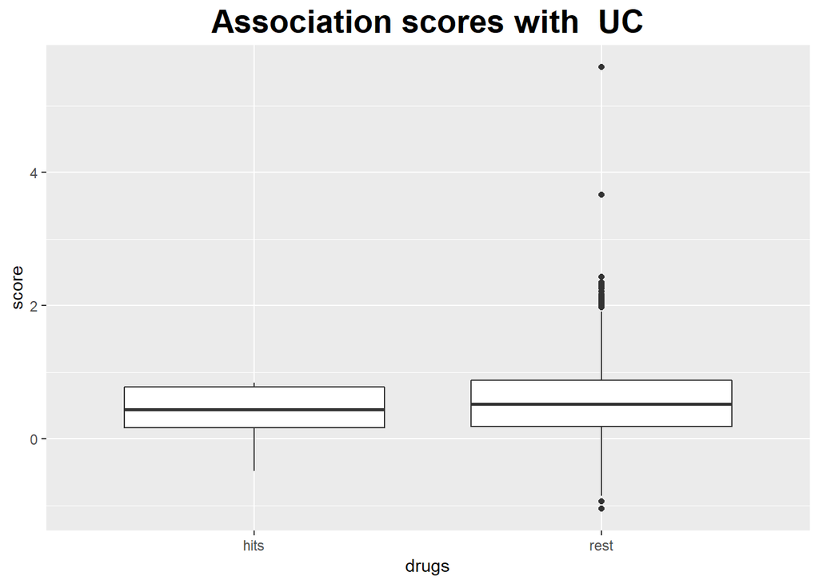

```
##
## $ranksum.test
##
##  Wilcoxon rank sum test with continuity correction
##
## data:  hits_scores and rest_scores
## W = 37682, p-value = 0.2312
## alternative hypothesis: true location shift is not equal to 0
##
##
## $student.test
##
##  Welch Two Sample t-test
##
## data:  hits_scores and rest_scores
## t = -2.6553, df = 19.701, p-value = 0.01531
## alternative hypothesis: true difference in means is not equal to 0
## 95 percent confidence interval:
##  -0.40496991 -0.04843849
## sample estimates:
## mean of x mean of y
## 0.3875466 0.6142508
##
##
## $hits
##  [1] "Mesalazine"                  "Morphine"
##  [3] "Beclomethasone dipropionate" "Betamethasone"
##  [5] "Prednisone"                  "Hydrocortisone"
##  [7] "Sulfasalazine"               "Loperamide"
##  [9] "Prednisolone"                "Neomycin"
## [11] "Cromoglicic acid"            "Balsalazide"
## [13] "Diphenoxylate"               "Streptomycin"
## [15] "Miconazole"                  "Rifaximin"
## [17] "Budesonide"                  "Olsalazine"
## [19] "Tixocortol"                  "Opium"
##
## $rest_high_score
##  [1] Chloroquine
##  [2] Phenacemide
##  [3] Phenazopyridine
```

[output cut: 29 more lines]

```
## [33] 2-[5,6-BIS-(4-METHOXY-PHENYL)-FURO[2,3-D]PYRIMIDIN-4-YLAMINO]-ETHANOL
## [34] 2-[(5,6-DIPHENYLFURO[2,3-D]PYRIMIDIN-4-YL)AMINO]ETHANOL
## [35] REL-(9R,12S)-9,10,11,12-TETRAHYDRO-9,12-EPOXY-1H-DIINDOLO[1,2,3-FG:3',2',1'-KL]PYRROLO[3,4-I][1,6]BENZODIAZOCINE-1,3(2H)-DIONE
## [36] 1-[(2S)-4-(5-phenyl-1H-pyrazolo[3,4-b]pyridin-4-yl)morpholin-2-yl]methanamine
## [37] N-(4-OXO-5,6,7,8-TETRAHYDRO-4H-[1,3]THIAZOLO[5,4-C]AZEPIN-2-YL)ACETAMIDE
## [38] 5,6,7,8-TETRAHYDRO[1]BENZOTHIENO[2,3-D]PYRIMIDIN-4(3H)-ONE
## [39] [4-amino-2-(tert-butylamino)-1,3-thiazol-5-yl](phenyl)methanone
## [40] 2-(methylsulfanyl)-5-(thiophen-2-ylmethyl)-1H-imidazol-4-ol
## [41] 6-MORPHOLIN-4-YL-9H-PURINE
## [42] 1-[(2S)-4-(5-BROMO-1H-PYRAZOLO[3,4-B]PYRIDIN-4-YL)MORPHOLIN-2-YL]METHANAMINE
## [43] Gabapentin Enacarbil
## [44] Alirocumab
## [45] Potassium perchlorate
## [46] Dichlorobenzyl alcohol
## 4459 Levels: '5'-O-(N-(L-Alanyl)-Sulfamoyl)Adenosine ...
```

```r
keywords=c('ulcerative colitis','corticosteroids','glucocorticoid')
categories=c('Intestinal Antiinflammatory Agents','Antidiarrheals, Intestinal Antiinflammatory/antiinfective Agents')
trait='UC'
find_hits_to_vis(keywords,categories,trait,DB_tar,lR)
```

##### Schizophrenia:

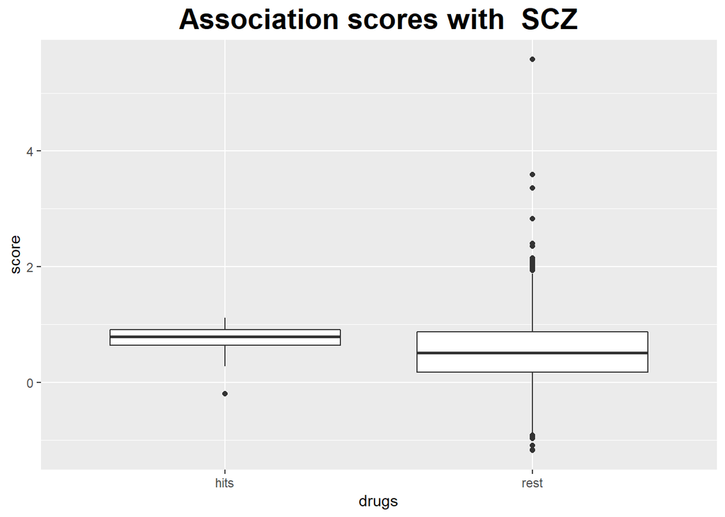

```
##
## $ranksum.test
##
##  Wilcoxon rank sum test with continuity correction
##
## data:  hits_scores and rest_scores
## W = 183070, p-value = 1.601e-05
## alternative hypothesis: true location shift is not equal to 0
##
##
## $student.test
##
##  Welch Two Sample t-test
##
## data:  hits_scores and rest_scores
```

[output cut: 270 more lines]

```r
keywords=c('schizophrenia','antipsychotic','antidepressant','psychoses')
categories=c('Antipsychotic Agents','Antipsychotic Agents (Second Generation [Atypical])')
trait='SCZ'

find_hits_to_vis(keywords,categories,trait,DB_tar,lR)
```

```r
pdf('Figures/SCZ_boxplot.pdf')
find_hits_to_vis(keywords,categories,trait,DB_tar,lR)$plot
dev.off()
```

##### High density lipids (HDL cholesterol):

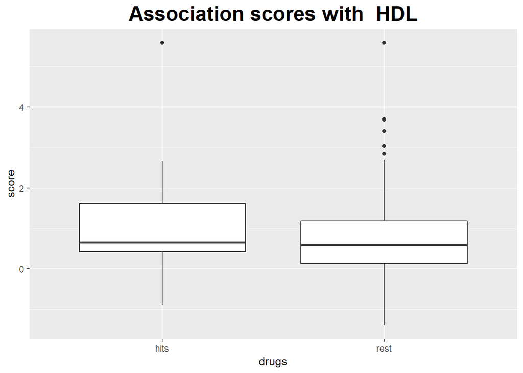

```
##
## $ranksum.test
##
##  Wilcoxon rank sum test with continuity correction
##
## data:  hits_scores and rest_scores
## W = 81772, p-value = 0.1447
## alternative hypothesis: true location shift is not equal to 0
##
##
## $student.test
##
##  Welch Two Sample t-test
##
## data:  hits_scores and rest_scores
```

[output cut: 605 more lines]

```r
keywords=c('cholesterol ','HDL','lipids','statins','hypercholesterolaemia','HMG-CoA')
categories=c('Anticholesteremic Agents','Hypolipidemic Agents','Lipid Modifying Agents')
trait='HDL'
find_hits_to_vis(keywords,categories,trait,DB_tar,lR)
```

```r
pdf('Figures/HDL_boxplot.pdf')
find_hits_to_vis(keywords,categories,trait,DB_tar,lR)$plot
dev.off()
```

##### Low density lipids (LDL cholesterol):

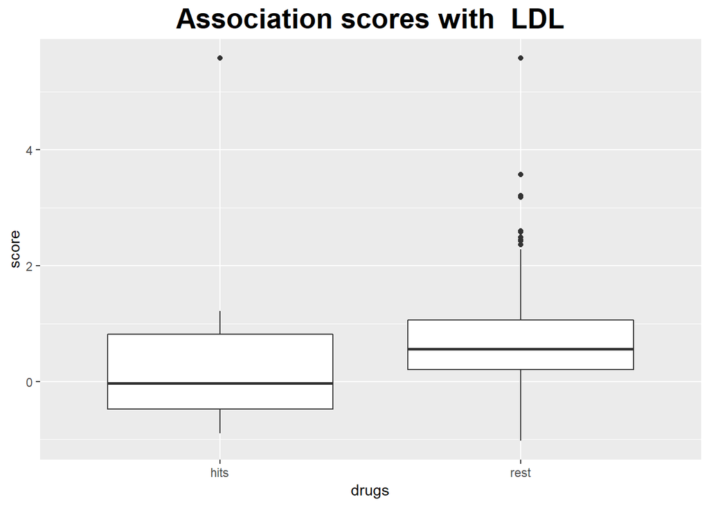

```
##
## $ranksum.test
##
##  Wilcoxon rank sum test with continuity correction
##
## data:  hits_scores and rest_scores
## W = 42862, p-value = 0.0001021
## alternative hypothesis: true location shift is not equal to 0
##
##
## $student.test
##
##  Welch Two Sample t-test
##
## data:  hits_scores and rest_scores
```

[output cut: 610 more lines]

```r
keywords=c('cholesterol ','LDL','lipids','statins','hypercholesterolaemia','HMG-CoA')
categories=c('Anticholesteremic Agents','Hypolipidemic Agents','Lipid Modifying Agents')
trait='LDL'
find_hits_to_vis(keywords,categories,trait,DB_tar,lR)
```

##### TC (total cholesterol):

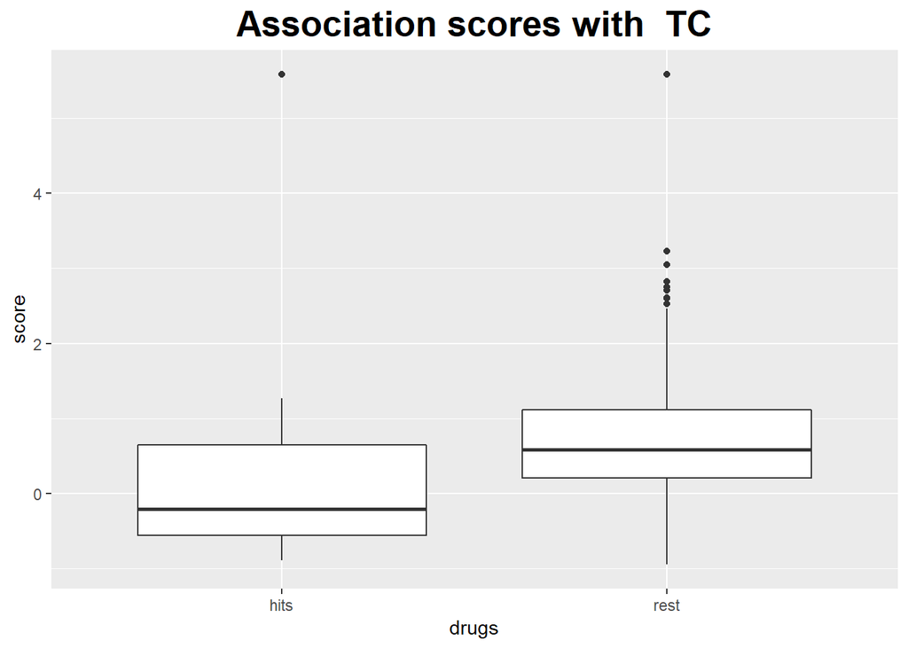

```
##
## $ranksum.test
##
##  Wilcoxon rank sum test with continuity correction
##
## data:  hits_scores and rest_scores
## W = 39764, p-value = 1.624e-05
## alternative hypothesis: true location shift is not equal to 0
##
##
## $student.test
##
##  Welch Two Sample t-test
##
## data:  hits_scores and rest_scores
```

[output cut: 607 more lines]

```r
keywords=c('cholesterol ','HDL','LDL','lipids','statins','hypercholesterolaemia','HMG-CoA')
categories=c('Anticholesteremic Agents','Hypolipidemic Agents','Lipid Modifying Agents')
trait='TC'
find_hits_to_vis(keywords,categories,trait,DB_tar,lR)
```

##### TG (High Triglycerid):

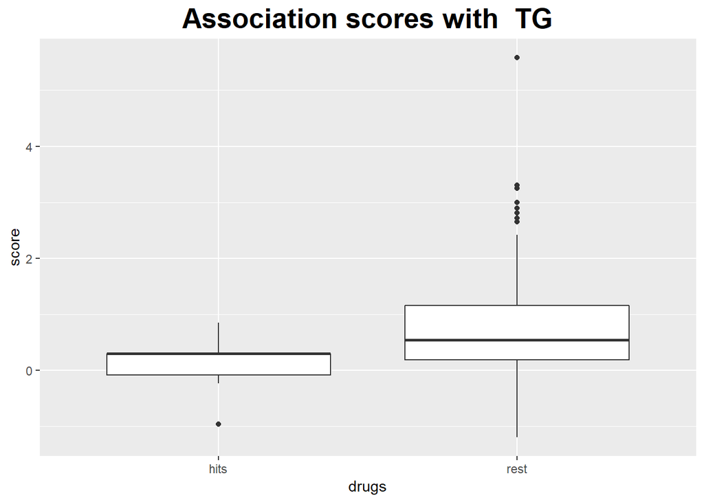

```
##
## $ranksum.test
##
##  Wilcoxon rank sum test with continuity correction
##
## data:  hits_scores and rest_scores
## W = 18640, p-value = 0.00894
## alternative hypothesis: true location shift is not equal to 0
##
##
## $student.test
##
##  Welch Two Sample t-test
##
## data:  hits_scores and rest_scores
```

[output cut: 614 more lines]

```r
keywords=c('hypertriglyeridemia ','triglyceride')
categories=c('Anticholesteremic Agents')
trait='TG'
find_hits_to_vis(keywords,categories,trait,DB_tar,lR)
```

##### HR (Every condition affecting heart rate):

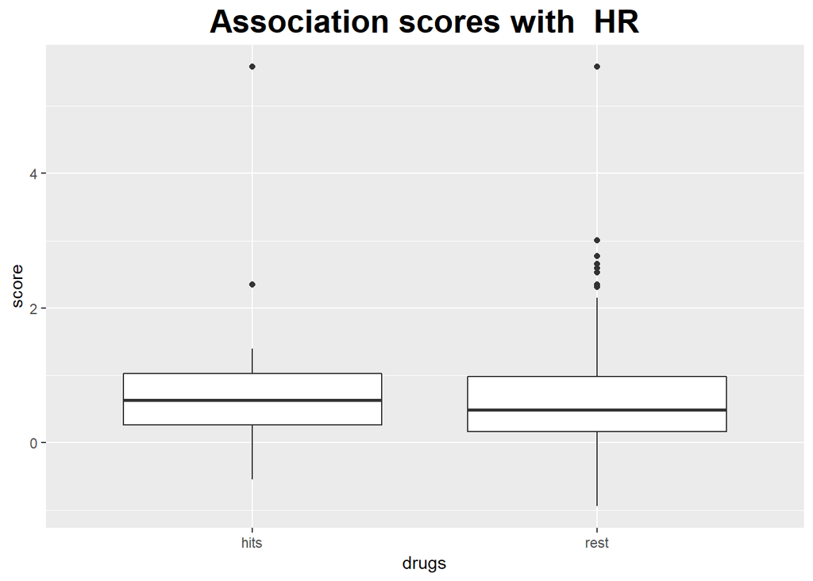

```
##
## $ranksum.test
##
##  Wilcoxon rank sum test with continuity correction
##
## data:  hits_scores and rest_scores
## W = 781250, p-value = 0.001754
## alternative hypothesis: true location shift is not equal to 0
##
##
## $student.test
##
##  Welch Two Sample t-test
##
## data:  hits_scores and rest_scores
```

[output cut: 897 more lines]

```r
keywords=c('heart failure ','stroke','cardiovascular events','myocardial infarction')
categories=c('Cardiovascular Agents','Hypotensive Agents','Cardiac Therapy','Cardiotonic Agents','Cardiac Stimulants Excl. Cardiac Glycosides')
trait='HR'
find_hits_to_vis(keywords,categories,trait,DB_tar,lR)
```